# Analysis of SARS-CoV-2 concentration in wastewater

2024-07-23

## Overview

This file produces a report of the wastewater concentration of SARS-CoV-2 in different counties in NJ. Data for this report was downloaded from the CDC website on 2024-07-23.

## Download and clean data

Two data sources were pulled and merged for this analysis. One is a dataset of SARS-CoV-2 wastewater concentration at different sampling sites, which can be accessed [here](https://data.cdc.gov/Public-Health-Surveillance/NWSS-Public-SARS-CoV-2-Concentration-in-Wastewater/g653-rqe2/about_data). The second, accessible [here](https://data.cdc.gov/Public-Health-Surveillance/NWSS-Public-SARS-CoV-2-Wastewater-Metric-Data/2ew6-ywp6/about_data), contains summary information about SARS-CoV-2 wastewater concentration at different sites, with additional information about site location including county and state.

First we downloaded and cleaned the data from the CDC website.

```r
if(params$download_raw_data){
  source(here("source", "01_data_download.R"))
}else if(!file.exists(here::here("data", "raw.Rdata"))){
  source(here("source", "01_data_download.R"))
}

source(here("source", "02_data_cleaning.R"))
```

## Analysis

Next we did a simple analysis of the concentrations across different counties in NJ. Specifically, we calculated the median and interquartile range within each county, which are given in the table below:

```r
source(here("source", "03_data_analysis.R"))
```

```r
covid_table %>%
  knitr::kable()
```

| county | median | q25 | q75 | population_served |
| --- | --- | --- | --- | --- |
| Essex,Hudson,Union,Passaic,Bergen | 3.439000e-04 | 1.410000e-04 | 7.366000e-04 | 1500000 |
| Monmouth | 7.051000e-04 | 2.137000e-04 | 4.336635e+08 | 52672 |
| Somerset | 1.102100e-03 | 3.125000e-04 | 5.661611e+08 | 130000 |
| Cumberland | 2.342532e+07 | 8.950000e-05 | 3.717667e+08 | 30000 |
| Essex,Union | 4.219920e+08 | 2.650610e+08 | 9.305707e+08 | 1300000 |
| Burlington | 5.933008e+08 | 1.106064e+08 | 3.956368e+09 | 19980 |
| Atlantic | 8.533049e+08 | 2.671336e+08 | 2.149539e+09 | 12000 |
| Hudson | 8.565144e+08 | 4.579705e+08 | 2.100901e+09 | 145000 |
| Morris | 9.545597e+08 | 4.268413e+08 | 1.932235e+09 | 24530 |
| Bergen | 1.243310e+09 | 6.894744e+08 | 2.446800e+09 | 564563 |
| Passaic | 1.306776e+09 | 6.342017e+08 | 2.533943e+09 | 54000 |
| Sussex | 1.340387e+09 | 6.235219e+08 | 3.403979e+09 | 7751 |
| Hunterdon | 1.344763e+09 | 5.251426e+08 | 4.017331e+09 | 9440 |
| Essex,Hudson,Passaic,Bergen | 1.395914e+09 | 9.015088e+08 | 2.691175e+09 | 1500000 |
| Union | 1.453446e+09 | 7.924719e+08 | 3.217677e+09 | 204148 |
| Middlesex,Somerset,Union | 1.540719e+09 | 8.859025e+08 | 3.410331e+09 | 880000 |
| Salem | 1.972146e+09 | 5.437832e+08 | 4.298083e+09 | 5500 |

# Visualization

Finally, we visualize the concentration across counties.

```r
source(here("source", "04_data_visualization.R"))
```

First we look at boxplots of the `log(concentration)` of SARS-CoV-2 across counties in NJ. The counties have been shorted from lowest to highest SARS-CoV-2 concentration.

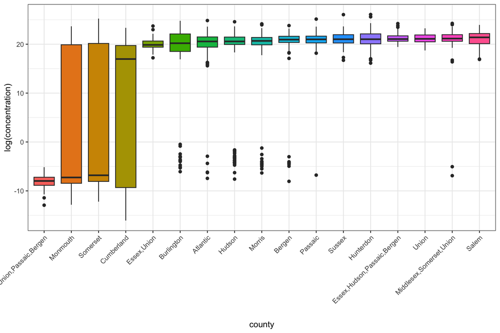

```r
plot1
```

Next, we visualize trends in SARS-CoV-2 concentration over time.

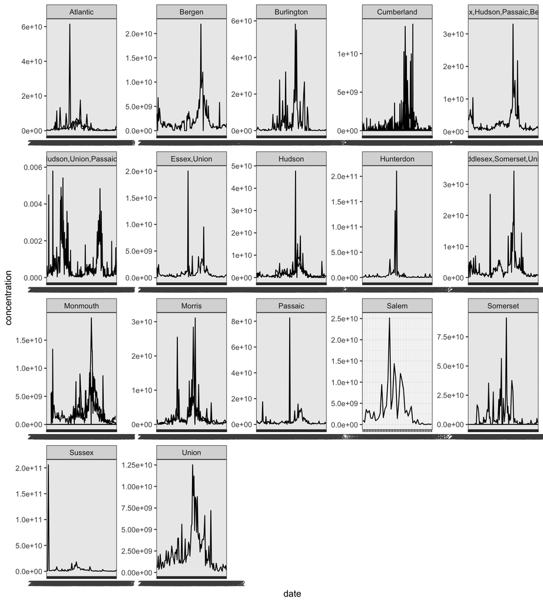

```r
plot2
```